# Flights Data set

## Preliminary Wrangling

> The original dataset reports domestic flights in the United States, including carriers, arrival and departure delays, and reasons for delays, from 1987 to 2008.

> I will analyze the data from 2008 data set. The data set can be downloaded from http://stat-computing.org/dataexpo/2009/the-data.html.

```python
# import modules
import pandas as pd
import numpy as np
import calendar
import datetime as dt

import matplotlib.pyplot as plt
import seaborn as sns
%matplotlib inline
```

```python
df= pd.read_csv('data/2008.csv', nrows=None, encoding='latin-1')
df.shape
```

```
(7009728, 29)
```

```python
df.sample()
```

|  | Year | Month | DayofMonth | DayOfWeek | DepTime | CRSDepTime | ArrTime | CRSArrTime | UniqueCarrier | FlightNum | ... | TaxiIn | TaxiOut | Cancelled | CancellationCode | Diverted | CarrierDelay | WeatherDelay | NASDelay | SecurityDelay | LateAircraftDelay |
| --- | --- | --- | --- | --- | --- | --- | --- | --- | --- | --- | --- | --- | --- | --- | --- | --- | --- | --- | --- | --- | --- |
| 3188835 | 2008 | 6 | 15 | 7 | 2113.0 | 1941 | 2337.0 | 2208 | OO | 6043 | ... | 4.0 | 16.0 | 0 | NaN | 0 | 0.0 | 89.0 | 0.0 | 0.0 | 0.0 |

1 rows × 29 columns

```python
# check shape
df.shape
```

```
(7009728, 29)
```

```python
# check df
df.head(10).T
```

|  | 0 | 1 | 2 | 3 | 4 | 5 | 6 | 7 | 8 | 9 |
| --- | --- | --- | --- | --- | --- | --- | --- | --- | --- | --- |
| Year | 2008 | 2008 | 2008 | 2008 | 2008 | 2008 | 2008 | 2008 | 2008 | 2008 |
| Month | 1 | 1 | 1 | 1 | 1 | 1 | 1 | 1 | 1 | 1 |
| DayofMonth | 3 | 3 | 3 | 3 | 3 | 3 | 3 | 3 | 3 | 3 |
| DayOfWeek | 4 | 4 | 4 | 4 | 4 | 4 | 4 | 4 | 4 | 4 |
| DepTime | 2003 | 754 | 628 | 926 | 1829 | 1940 | 1937 | 1039 | 617 | 1620 |
| CRSDepTime | 1955 | 735 | 620 | 930 | 1755 | 1915 | 1830 | 1040 | 615 | 1620 |
| ArrTime | 2211 | 1002 | 804 | 1054 | 1959 | 2121 | 2037 | 1132 | 652 | 1639 |
| CRSArrTime | 2225 | 1000 | 750 | 1100 | 1925 | 2110 | 1940 | 1150 | 650 | 1655 |
| UniqueCarrier | WN | WN | WN | WN | WN | WN | WN | WN | WN | WN |
| FlightNum | 335 | 3231 | 448 | 1746 | 3920 | 378 | 509 | 535 | 11 | 810 |
| TailNum | N712SW | N772SW | N428WN | N612SW | N464WN | N726SW | N763SW | N428WN | N689SW | N648SW |
| ActualElapsedTime | 128 | 128 | 96 | 88 | 90 | 101 | 240 | 233 | 95 | 79 |
| CRSElapsedTime | 150 | 145 | 90 | 90 | 90 | 115 | 250 | 250 | 95 | 95 |
| AirTime | 116 | 113 | 76 | 78 | 77 | 87 | 230 | 219 | 70 | 70 |
| ArrDelay | -14 | 2 | 14 | -6 | 34 | 11 | 57 | -18 | 2 | -16 |
| DepDelay | 8 | 19 | 8 | -4 | 34 | 25 | 67 | -1 | 2 | 0 |
| Origin | IAD | IAD | IND | IND | IND | IND | IND | IND | IND | IND |
| Dest | TPA | TPA | BWI | BWI | BWI | JAX | LAS | LAS | MCI | MCI |
| Distance | 810 | 810 | 515 | 515 | 515 | 688 | 1591 | 1591 | 451 | 451 |
| TaxiIn | 4 | 5 | 3 | 3 | 3 | 4 | 3 | 7 | 6 | 3 |
| TaxiOut | 8 | 10 | 17 | 7 | 10 | 10 | 7 | 7 | 19 | 6 |
| Cancelled | 0 | 0 | 0 | 0 | 0 | 0 | 0 | 0 | 0 | 0 |
| CancellationCode | NaN | NaN | NaN | NaN | NaN | NaN | NaN | NaN | NaN | NaN |
| Diverted | 0 | 0 | 0 | 0 | 0 | 0 | 0 | 0 | 0 | 0 |
| CarrierDelay | NaN | NaN | NaN | NaN | 2 | NaN | 10 | NaN | NaN | NaN |
| WeatherDelay | NaN | NaN | NaN | NaN | 0 | NaN | 0 | NaN | NaN | NaN |
| NASDelay | NaN | NaN | NaN | NaN | 0 | NaN | 0 | NaN | NaN | NaN |
| SecurityDelay | NaN | NaN | NaN | NaN | 0 | NaN | 0 | NaN | NaN | NaN |
| LateAircraftDelay | NaN | NaN | NaN | NaN | 32 | NaN | 47 | NaN | NaN | NaN |

```python
# check summary statistics
df.describe()
```

|  | Year | Month | DayofMonth | DayOfWeek | DepTime | CRSDepTime | ArrTime | CRSArrTime | FlightNum | ActualElapsedTime | ... | Distance | TaxiIn | TaxiOut | Cancelled | Diverted | CarrierDelay | WeatherDelay | NASDelay | SecurityDelay | LateAircraftDelay |
| --- | --- | --- | --- | --- | --- | --- | --- | --- | --- | --- | --- | --- | --- | --- | --- | --- | --- | --- | --- | --- | --- |
| count | 7009728.0 | 7.009728e+06 | 7.009728e+06 | 7.009728e+06 | 6.873482e+06 | 7.009728e+06 | 6.858079e+06 | 7.009728e+06 | 7.009728e+06 | 6.855029e+06 | ... | 7.009728e+06 | 6.858079e+06 | 6.872670e+06 | 7.009728e+06 | 7.009728e+06 | 1.524735e+06 | 1.524735e+06 | 1.524735e+06 | 1.524735e+06 | 1.524735e+06 |
| mean | 2008.0 | 6.375130e+00 | 1.572801e+01 | 3.924182e+00 | 1.333830e+03 | 1.326086e+03 | 1.481258e+03 | 1.494801e+03 | 2.224200e+03 | 1.273224e+02 | ... | 7.263870e+02 | 6.860852e+00 | 1.645305e+01 | 1.960618e-02 | 2.463006e-03 | 1.577206e+01 | 3.039031e+00 | 1.716462e+01 | 7.497434e-02 | 2.077098e+01 |
| std | 0.0 | 3.406737e+00 | 8.797068e+00 | 1.988259e+00 | 4.780689e+02 | 4.642509e+02 | 5.052251e+02 | 4.826728e+02 | 1.961716e+03 | 7.018731e+01 | ... | 5.621018e+02 | 4.933649e+00 | 1.133280e+01 | 1.386426e-01 | 4.956753e-02 | 4.009912e+01 | 1.950287e+01 | 3.189495e+01 | 1.837940e+00 | 3.925964e+01 |
| min | 2008.0 | 1.000000e+00 | 1.000000e+00 | 1.000000e+00 | 1.000000e+00 | 0.000000e+00 | 1.000000e+00 | 0.000000e+00 | 1.000000e+00 | 1.200000e+01 | ... | 1.100000e+01 | 0.000000e+00 | 0.000000e+00 | 0.000000e+00 | 0.000000e+00 | 0.000000e+00 | 0.000000e+00 | 0.000000e+00 | 0.000000e+00 | 0.000000e+00 |
| 25% | 2008.0 | 3.000000e+00 | 8.000000e+00 | 2.000000e+00 | 9.280000e+02 | 9.250000e+02 | 1.107000e+03 | 1.115000e+03 | 6.220000e+02 | 7.700000e+01 | ... | 3.250000e+02 | 4.000000e+00 | 1.000000e+01 | 0.000000e+00 | 0.000000e+00 | 0.000000e+00 | 0.000000e+00 | 0.000000e+00 | 0.000000e+00 | 0.000000e+00 |
| 50% | 2008.0 | 6.000000e+00 | 1.600000e+01 | 4.000000e+00 | 1.325000e+03 | 1.320000e+03 | 1.512000e+03 | 1.517000e+03 | 1.571000e+03 | 1.100000e+02 | ... | 5.810000e+02 | 6.000000e+00 | 1.400000e+01 | 0.000000e+00 | 0.000000e+00 | 0.000000e+00 | 0.000000e+00 | 6.000000e+00 | 0.000000e+00 | 0.000000e+00 |
| 75% | 2008.0 | 9.000000e+00 | 2.300000e+01 | 6.000000e+00 | 1.728000e+03 | 1.715000e+03 | 1.909000e+03 | 1.907000e+03 | 3.518000e+03 | 1.570000e+02 | ... | 9.540000e+02 | 8.000000e+00 | 1.900000e+01 | 0.000000e+00 | 0.000000e+00 | 1.600000e+01 | 0.000000e+00 | 2.100000e+01 | 0.000000e+00 | 2.600000e+01 |
| max | 2008.0 | 1.200000e+01 | 3.100000e+01 | 7.000000e+00 | 2.400000e+03 | 2.359000e+03 | 2.400000e+03 | 2.400000e+03 | 9.743000e+03 | 1.379000e+03 | ... | 4.962000e+03 | 3.080000e+02 | 4.290000e+02 | 1.000000e+00 | 1.000000e+00 | 2.436000e+03 | 1.352000e+03 | 1.357000e+03 | 3.920000e+02 | 1.316000e+03 |

8 rows × 24 columns

```python
# check null
df.isna().sum()
```

```
Year                       0
Month                      0
DayofMonth                 0
DayOfWeek                  0
DepTime               136246
CRSDepTime                 0
ArrTime               151649
CRSArrTime                 0
UniqueCarrier              0
FlightNum                  0
TailNum                83365
ActualElapsedTime     154699
CRSElapsedTime           844
AirTime               154699
ArrDelay              154699
DepDelay              136246
Origin                     0
Dest                       0
Distance                   0
TaxiIn                151649
TaxiOut               137058
Cancelled                  0
CancellationCode     6872294
Diverted                   0
CarrierDelay         5484993
WeatherDelay         5484993
NASDelay             5484993
SecurityDelay        5484993
LateAircraftDelay    5484993
dtype: int64
```

```python
df.info()
```

```
<class 'pandas.core.frame.DataFrame'>
RangeIndex: 7009728 entries, 0 to 7009727
Data columns (total 29 columns):
Year                 int64
Month                int64
DayofMonth           int64
DayOfWeek            int64
DepTime              float64
CRSDepTime           int64
ArrTime              float64
CRSArrTime           int64
UniqueCarrier        object
FlightNum            int64
TailNum              object
ActualElapsedTime    float64
CRSElapsedTime       float64
AirTime              float64
ArrDelay             float64
DepDelay             float64
Origin               object
Dest                 object
Distance             int64
TaxiIn               float64
TaxiOut              float64
Cancelled            int64
CancellationCode     object
Diverted             int64
CarrierDelay         float64
WeatherDelay         float64
NASDelay             float64
SecurityDelay        float64
LateAircraftDelay    float64
dtypes: float64(14), int64(10), object(5)
memory usage: 1.5+ GB
```

```python
# check cancelled values und total no. for each
df.groupby("Cancelled").size().sort_values(ascending=False)
```

```
Cancelled
0    6872294
1     137434
dtype: int64
```

```python
df.groupby("CancellationCode").size().sort_values(ascending=False)
```

```
CancellationCode
B    54904
A    54330
C    28188
D       12
dtype: int64
```

```python
df.groupby("Diverted").size().sort_values(ascending=False)
```

```
Diverted
0    6992463
1      17265
dtype: int64
```

```python
# check columns name
df.columns
```

```
Index(['Year', 'Month', 'DayofMonth', 'DayOfWeek', 'DepTime', 'CRSDepTime',
       'ArrTime', 'CRSArrTime', 'UniqueCarrier', 'FlightNum', 'TailNum',
       'ActualElapsedTime', 'CRSElapsedTime', 'AirTime', 'ArrDelay',
       'DepDelay', 'Origin', 'Dest', 'Distance', 'TaxiIn', 'TaxiOut',
       'Cancelled', 'CancellationCode', 'Diverted', 'CarrierDelay',
       'WeatherDelay', 'NASDelay', 'SecurityDelay', 'LateAircraftDelay'],
      dtype='object')
```

### What is the structure of your dataset?

> There are 7009728 observations in total in 2008. A number of columns is 29 for the data set. Before we start analyzing data, data cleaning is essential. Following points should be checked in the data set.

### Quality issue

- missing value for DepTime and ArrTime as well as ArrDelay and DepDelay
- missing CancellationCode
- missing CarrierDelay, WeatherDelay, NASDelay, SecurityDelay and LateAircraftDelay
- Cancelled is int64
- CancellationCode is object
- Year, Month, DayofMonth and DayOfWeek are int
- DepTime, ArrTime are float64
- ArrDelay, DepDelay are float64
- CarrierDelay, WeatherDelay, NASDelay, SecurityDelay and LateAircraftDelay are float64

### Structure issue

- There are un necessary columns

## Clean

### Define

- Add date Column

### Code

```python
df['Date'] = pd.to_datetime(df.Year*10000+df.Month*100+df.DayofMonth,format='%Y%m%d')
```

### Test

```python
df.head(2)
```

|  | Year | Month | DayofMonth | DayOfWeek | DepTime | CRSDepTime | ArrTime | CRSArrTime | UniqueCarrier | FlightNum | ... | TaxiOut | Cancelled | CancellationCode | Diverted | CarrierDelay | WeatherDelay | NASDelay | SecurityDelay | LateAircraftDelay | Date |
| --- | --- | --- | --- | --- | --- | --- | --- | --- | --- | --- | --- | --- | --- | --- | --- | --- | --- | --- | --- | --- | --- |
| 0 | 2008 | 1 | 3 | 4 | 2003.0 | 1955 | 2211.0 | 2225 | WN | 335 | ... | 8.0 | 0 | NaN | 0 | NaN | NaN | NaN | NaN | NaN | 2008-01-03 |
| 1 | 2008 | 1 | 3 | 4 | 754.0 | 735 | 1002.0 | 1000 | WN | 3231 | ... | 10.0 | 0 | NaN | 0 | NaN | NaN | NaN | NaN | NaN | 2008-01-03 |

2 rows × 30 columns

```python
df.info()
```

```
<class 'pandas.core.frame.DataFrame'>
RangeIndex: 7009728 entries, 0 to 7009727
Data columns (total 30 columns):
Year                 int64
Month                int64
DayofMonth           int64
DayOfWeek            int64
DepTime              float64
CRSDepTime           int64
ArrTime              float64
CRSArrTime           int64
UniqueCarrier        object
FlightNum            int64
TailNum              object
ActualElapsedTime    float64
CRSElapsedTime       float64
AirTime              float64
ArrDelay             float64
DepDelay             float64
Origin               object
Dest                 object
Distance             int64
TaxiIn               float64
TaxiOut              float64
Cancelled            int64
CancellationCode     object
Diverted             int64
CarrierDelay         float64
WeatherDelay         float64
NASDelay             float64
SecurityDelay        float64
LateAircraftDelay    float64
Date                 datetime64[ns]
dtypes: datetime64[ns](1), float64(14), int64(10), object(5)
memory usage: 1.6+ GB
```

```python
df.info(null_counts=True)
```

```
<class 'pandas.core.frame.DataFrame'>
RangeIndex: 7009728 entries, 0 to 7009727
Data columns (total 30 columns):
Year                 7009728 non-null int64
Month                7009728 non-null int64
DayofMonth           7009728 non-null int64
DayOfWeek            7009728 non-null int64
DepTime              6873482 non-null float64
CRSDepTime           7009728 non-null int64
ArrTime              6858079 non-null float64
CRSArrTime           7009728 non-null int64
UniqueCarrier        7009728 non-null object
FlightNum            7009728 non-null int64
TailNum              6926363 non-null object
ActualElapsedTime    6855029 non-null float64
CRSElapsedTime       7008884 non-null float64
AirTime              6855029 non-null float64
ArrDelay             6855029 non-null float64
DepDelay             6873482 non-null float64
Origin               7009728 non-null object
Dest                 7009728 non-null object
Distance             7009728 non-null int64
TaxiIn               6858079 non-null float64
TaxiOut              6872670 non-null float64
Cancelled            7009728 non-null int64
CancellationCode     137434 non-null object
Diverted             7009728 non-null int64
CarrierDelay         1524735 non-null float64
WeatherDelay         1524735 non-null float64
NASDelay             1524735 non-null float64
SecurityDelay        1524735 non-null float64
LateAircraftDelay    1524735 non-null float64
Date                 7009728 non-null datetime64[ns]
dtypes: datetime64[ns](1), float64(14), int64(10), object(5)
memory usage: 1.6+ GB
```

### Define

- convert CancellationCode into ordered categorical types

### Code

```python
CancellationCode_dict = {'CancellationCode': ['A','B','C','D']}

for var in CancellationCode_dict:
    CancellationCode_var = pd.api.types.CategoricalDtype(ordered = True,categories = CancellationCode_dict[var])
    df[var] = df[var].astype(CancellationCode_var)
```

### Test

```python
df.info()
```

```
<class 'pandas.core.frame.DataFrame'>
RangeIndex: 7009728 entries, 0 to 7009727
Data columns (total 30 columns):
Year                 int64
Month                int64
DayofMonth           int64
DayOfWeek            int64
DepTime              float64
CRSDepTime           int64
ArrTime              float64
CRSArrTime           int64
UniqueCarrier        object
FlightNum            int64
TailNum              object
ActualElapsedTime    float64
CRSElapsedTime       float64
AirTime              float64
ArrDelay             float64
DepDelay             float64
Origin               object
Dest                 object
Distance             int64
TaxiIn               float64
TaxiOut              float64
Cancelled            int64
CancellationCode     category
Diverted             int64
CarrierDelay         float64
WeatherDelay         float64
NASDelay             float64
SecurityDelay        float64
LateAircraftDelay    float64
Date                 datetime64[ns]
dtypes: category(1), datetime64[ns](1), float64(14), int64(10), object(4)
memory usage: 1.5+ GB
```

### Define

- Create a data set for cancelled flight
- Create a column to describe the CancellationCode
- Change Cancelled column Type from Int to Boolean

```python
# create a copy of the dataset only for cancelled flights
df_cancelled = df.copy()
df_cancelled.drop(['DepTime','CRSDepTime','ArrTime', 'CRSArrTime',
                   'UniqueCarrier', 'FlightNum', 'TailNum','ActualElapsedTime',
                   'CRSElapsedTime', 'AirTime', 'ArrDelay','DepDelay', 'Origin',
                   'Dest', 'Distance', 'TaxiIn', 'TaxiOut','Diverted', 'CarrierDelay',
                   'WeatherDelay', 'NASDelay', 'SecurityDelay', 'LateAircraftDelay'], axis=1, inplace=True)
```

```python
# Create a column to describe the CancellationCode
df_cancelled['Cancellation_Desc'] = df_cancelled.CancellationCode.map({'A':'Carrier', 'B':'Weather', 'C':'NAS', 'D':'Security'})
```

```python
df_cancelled['Cancelled'] = df_cancelled['Cancelled'].astype('bool')
```

### Test

```python
# View the dataset
#df_cancelled.query("Cancelled == 1 ")
```

```python
df_cancelled.head(2)
```

|  | Year | Month | DayofMonth | DayOfWeek | Cancelled | CancellationCode | Date | Cancellation_Desc |
| --- | --- | --- | --- | --- | --- | --- | --- | --- |
| 0 | 2008 | 1 | 3 | 4 | False | NaN | 2008-01-03 | NaN |
| 1 | 2008 | 1 | 3 | 4 | False | NaN | 2008-01-03 | NaN |

```python
df_cancelled.shape
```

```
(7009728, 8)
```

```python
df_cancelled.info()
```

```
<class 'pandas.core.frame.DataFrame'>
RangeIndex: 7009728 entries, 0 to 7009727
Data columns (total 8 columns):
Year                 int64
Month                int64
DayofMonth           int64
DayOfWeek            int64
Cancelled            bool
CancellationCode     category
Date                 datetime64[ns]
Cancellation_Desc    object
dtypes: bool(1), category(1), datetime64[ns](1), int64(4), object(1)
memory usage: 334.3+ MB
```

### Define

- Create a data set for Diverted flight
- Create a column to describe the CancellationCode
- Change Diverted column Type from Int to Boolean

### Code

```python
# create a copy of the dataset only for Diverted flights and delete un necessary columns
df_diverted = df.copy()
df_diverted.drop(['DepTime', 'CRSDepTime','ArrTime', 'CRSArrTime', 'UniqueCarrier', 'FlightNum', 'TailNum','ActualElapsedTime', 'CRSElapsedTime', 'AirTime', 'ArrDelay','DepDelay', 'Origin', 'Dest', 'Distance', 'TaxiIn', 'TaxiOut','Cancelled', 'CancellationCode', 'CarrierDelay','WeatherDelay', 'NASDelay', 'SecurityDelay', 'LateAircraftDelay'], axis=1, inplace=True)
```

```python
df_diverted['Diverted'] = df_diverted['Diverted'].astype('bool')
```

### Test

```python
df_diverted.sample(2)
```

|  | Year | Month | DayofMonth | DayOfWeek | Diverted | Date |
| --- | --- | --- | --- | --- | --- | --- |
| 4232622 | 2008 | 8 | 2 | 6 | False | 2008-08-02 |
| 2945048 | 2008 | 5 | 25 | 7 | False | 2008-05-25 |

```python
df_diverted.info()
```

```
<class 'pandas.core.frame.DataFrame'>
RangeIndex: 7009728 entries, 0 to 7009727
Data columns (total 6 columns):
Year          int64
Month         int64
DayofMonth    int64
DayOfWeek     int64
Diverted      bool
Date          datetime64[ns]
dtypes: bool(1), datetime64[ns](1), int64(4)
memory usage: 274.1 MB
```

```python
df_diverted.groupby("Diverted").size().sort_values(ascending=False)
```

```
Diverted
False    6992463
True       17265
dtype: int64
```

### Code

```python
df_flights =  df.copy()
```

```python
# drop un necessary columns

df_flights.drop([ 'CRSArrTime','TailNum', 'FlightNum', 'TaxiIn','TaxiOut', 'ActualElapsedTime','CRSElapsedTime','Cancelled', 'CancellationCode', ], axis=1, inplace=True)
```

### Test

```python
df_flights.columns
```

```
Index(['Year', 'Month', 'DayofMonth', 'DayOfWeek', 'DepTime', 'CRSDepTime',
       'ArrTime', 'UniqueCarrier', 'AirTime', 'ArrDelay', 'DepDelay', 'Origin',
       'Dest', 'Distance', 'Diverted', 'CarrierDelay', 'WeatherDelay',
       'NASDelay', 'SecurityDelay', 'LateAircraftDelay', 'Date'],
      dtype='object')
```

```python
#colums to keep
fields = ['Year', 'Month', 'DayofMonth', 'DayOfWeek', 'ArrDelay', 'CarrierDelay',
       'WeatherDelay', 'NASDelay', 'SecurityDelay', 'LateAircraftDelay' ]
```

```python
df_flights.isna().sum()
```

```
Year                       0
Month                      0
DayofMonth                 0
DayOfWeek                  0
DepTime               136246
CRSDepTime                 0
ArrTime               151649
UniqueCarrier              0
AirTime               154699
ArrDelay              154699
DepDelay              136246
Origin                     0
Dest                       0
Distance                   0
Diverted                   0
CarrierDelay         5484993
WeatherDelay         5484993
NASDelay             5484993
SecurityDelay        5484993
LateAircraftDelay    5484993
Date                       0
dtype: int64
```

```python
df_flights.sample()
```

|  | Year | Month | DayofMonth | DayOfWeek | DepTime | CRSDepTime | ArrTime | UniqueCarrier | AirTime | ArrDelay | ... | Origin | Dest | Distance | Diverted | CarrierDelay | WeatherDelay | NASDelay | SecurityDelay | LateAircraftDelay | Date |
| --- | --- | --- | --- | --- | --- | --- | --- | --- | --- | --- | --- | --- | --- | --- | --- | --- | --- | --- | --- | --- | --- |
| 3548898 | 2008 | 6 | 21 | 6 | 642.0 | 645 | 948.0 | B6 | 163.0 | 4.0 | ... | JFK | RSW | 1074 | 0 | NaN | NaN | NaN | NaN | NaN | 2008-06-21 |

1 rows × 21 columns

```python
df_flights.shape
```

```
(7009728, 21)
```

### Define

Manage missing values, Null values from the original dataset

### Code

```python
df_flights.dropna(subset=['DepTime'], inplace=True)
```

```python
df_flights.shape
```

```
(6873482, 21)
```

```python
df_flights.isna().sum()
```

```
Year                       0
Month                      0
DayofMonth                 0
DayOfWeek                  0
DepTime                    0
CRSDepTime                 0
ArrTime                15403
UniqueCarrier              0
AirTime                18453
ArrDelay               18453
DepDelay                   0
Origin                     0
Dest                       0
Distance                   0
Diverted                   0
CarrierDelay         5348747
WeatherDelay         5348747
NASDelay             5348747
SecurityDelay        5348747
LateAircraftDelay    5348747
Date                       0
dtype: int64
```

```python
df_flights.dropna(subset=['ArrTime'], inplace=True)
```

```python
df_flights.isna().sum()
```

```
Year                       0
Month                      0
DayofMonth                 0
DayOfWeek                  0
DepTime                    0
CRSDepTime                 0
ArrTime                    0
UniqueCarrier              0
AirTime                 3050
ArrDelay                3050
DepDelay                   0
Origin                     0
Dest                       0
Distance                   0
Diverted                   0
CarrierDelay         5333344
WeatherDelay         5333344
NASDelay             5333344
SecurityDelay        5333344
LateAircraftDelay    5333344
Date                       0
dtype: int64
```

```python
df_flights.dropna(subset=['ArrDelay'], inplace=True)
```

```python
df_flights.isna().sum()
```

```
Year                       0
Month                      0
DayofMonth                 0
DayOfWeek                  0
DepTime                    0
CRSDepTime                 0
ArrTime                    0
UniqueCarrier              0
AirTime                    0
ArrDelay                   0
DepDelay                   0
Origin                     0
Dest                       0
Distance                   0
Diverted                   0
CarrierDelay         5330294
WeatherDelay         5330294
NASDelay             5330294
SecurityDelay        5330294
LateAircraftDelay    5330294
Date                       0
dtype: int64
```

### Test

```python
df_flights.isna().sum()
```

```
Year                       0
Month                      0
DayofMonth                 0
DayOfWeek                  0
DepTime                    0
CRSDepTime                 0
ArrTime                    0
UniqueCarrier              0
AirTime                    0
ArrDelay                   0
DepDelay                   0
Origin                     0
Dest                       0
Distance                   0
Diverted                   0
CarrierDelay         5330294
WeatherDelay         5330294
NASDelay             5330294
SecurityDelay        5330294
LateAircraftDelay    5330294
Date                       0
dtype: int64
```

```python
df_flights.shape
```

```
(6855029, 21)
```

```python
df_clean= df_flights.copy()
```

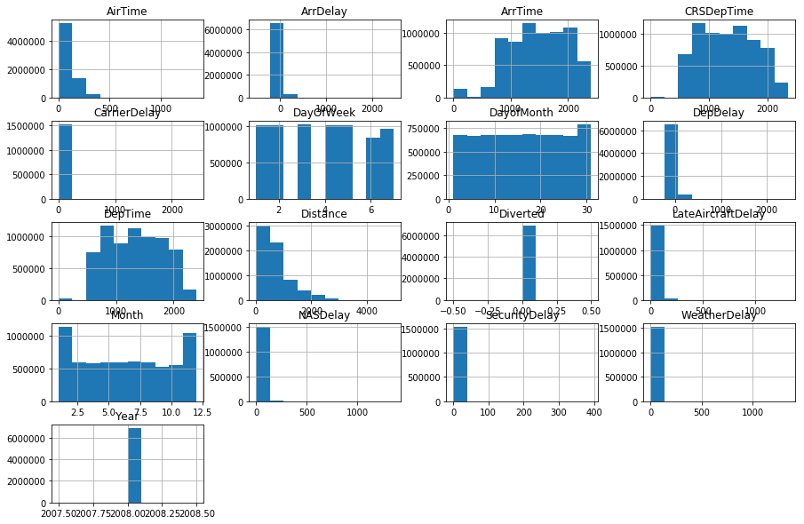

```python
# check qucik histogram
df_clean.hist(figsize=[15, 10]);
```

### What is/are the main feature(s) of interest in your dataset?

> - Cancelled Flights, What is the main reason behind the Cancelling flights, and what Cancelled Flights ratio.
> - Diverted Flights, What is the Diverted Flights ratio
> - Delayed Flights, What is the main reason behind delaying flights, and what delayed Flights ratio.
> - The Distance and Distance vs. AirTime¶

### What features in the dataset do you think will help support your investigation into your feature(s) of interest?

- Year', 'Month', 'DayofMonth', 'DayOfWeek', 'DepTime', 'CRSDepTime', 'ArrTime', 'AirTime', 'ArrDelay', 'DepDelay', 'Distance', ,'Cancelled', 'CancellationCode', 'Diverted', 'CarrierDelay','WeatherDelay', 'NASDelay', 'SecurityDelay', 'LateAircraftDelay'],

  > With these variables I should be able to find some insights.

## Univariate Exploration

> **What is/are the main reason/s for flight cancellation**

```python
can_order = df_cancelled['Cancellation_Desc'].value_counts()
can_order
```

```
Weather     54904
Carrier     54330
NAS         28188
Security       12
Name: Cancellation_Desc, dtype: int64
```

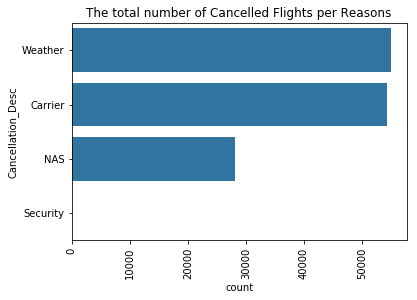

```python
base_color = sns.color_palette()[0]
can_order = df_cancelled['Cancellation_Desc'].value_counts().index
sns.countplot(data = df_cancelled, y = 'Cancellation_Desc', color = base_color, order = can_order)
plt.xticks(rotation = 90)
plt.title("The total number of Cancelled Flights per Reasons");
```

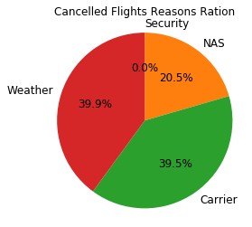

```python
can_flights_Desc = df_cancelled.groupby("Cancellation_Desc").size()
sorted_Desc = can_flights_Desc.sort_values()
plt.pie(sorted_Desc, labels = sorted_Desc.index, startangle = 90, counterclock = False, autopct = '%1.1f%%',
       textprops=dict( color = "black", size = 12))
plt.axis("square")
plt.title("Cancelled Flights Reasons Ration");
```

> **Which month/s occur more cancellation**

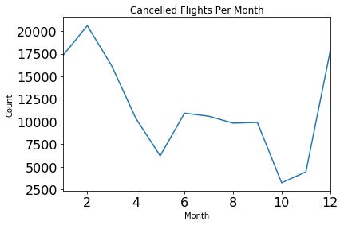

```python
df_cancelled[['Month','Cancellation_Desc']].groupby(['Month']).count().plot(kind='line', grid=False, fontsize=16)
plt.title("Cancelled Flights Per Month")
plt.ylabel("Count")
plt.legend().remove()
plt.show();
```

> **What is the Cancelled flight ratio**

```python
can_flights = df_cancelled['Cancelled'].value_counts()
can_flights
```

```
False    6872294
True      137434
Name: Cancelled, dtype: int64
```

> **What is the Cancelled flight ratio**

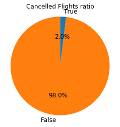

```python
# plot Cancelled VS all flights
can_flights = df_cancelled.groupby("Cancelled").size()
sorted_counts = can_flights.sort_values()
plt.pie(sorted_counts, labels = sorted_counts.index, startangle = 90, counterclock = False, autopct = '%1.1f%%',
       textprops=dict(color = "black", size = 12))
plt.axis("square")
plt.title("Cancelled Flights ratio");
```

> The ratio of cancelled flights to all the flights might seem pretty low. However, in reality 2 percent of 7 million is 137434. That is a respectably high number.

> **What is the diverted flight ratio**

```python
div_flights = df_diverted['Diverted'].value_counts()
div_flights
```

```
False    6992463
True       17265
Name: Diverted, dtype: int64
```

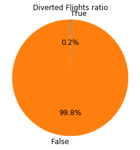

```python
# plot Cancelled VS all flights
div_flights = df_diverted.groupby("Diverted").size()
sorted_counts_div = div_flights.sort_values()
plt.pie(sorted_counts_div, labels = sorted_counts_div.index, startangle = 90, counterclock = False, autopct = '%1.1f%%',textprops=dict(color = "black", size = 12))
plt.axis("square")
plt.title("Diverted Flights ratio");
```

> The percentage of diverted flights is much lower than the percentage of cancelled flights. 0.2 percent of 7 million is only 17,265. That is almost 8 times less than the amount of cancelled flights

> **What is the delayed flight ratio**

```python
df_clean['Delayed'] = df_clean['DepDelay']>=15
df_clean.head(2)
```

|  | Year | Month | DayofMonth | DayOfWeek | DepTime | CRSDepTime | ArrTime | UniqueCarrier | AirTime | ArrDelay | ... | Dest | Distance | Diverted | CarrierDelay | WeatherDelay | NASDelay | SecurityDelay | LateAircraftDelay | Date | Delayed |
| --- | --- | --- | --- | --- | --- | --- | --- | --- | --- | --- | --- | --- | --- | --- | --- | --- | --- | --- | --- | --- | --- |
| 0 | 2008 | 1 | 3 | 4 | 2003.0 | 1955 | 2211.0 | WN | 116.0 | -14.0 | ... | TPA | 810 | 0 | NaN | NaN | NaN | NaN | NaN | 2008-01-03 | False |
| 1 | 2008 | 1 | 3 | 4 | 754.0 | 735 | 1002.0 | WN | 113.0 | 2.0 | ... | TPA | 810 | 0 | NaN | NaN | NaN | NaN | NaN | 2008-01-03 | True |

2 rows × 22 columns

> **Note**: A flight delay is when an airline flight takes off and/or lands later than its scheduled time. The Federal Aviation Administration (FAA) considers a flight to be delayed when it is 15 minutes later than its scheduled time. A cancellation occurs when the airline does not operate the flight at all for a certain reason. https://en.wikipedia.org/wiki/Flight_cancellation_and_delay

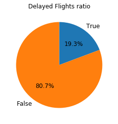

```python
df_ratio = df_clean.groupby("Delayed").size()
sorted_counts_df_ratio = df_ratio.sort_values()
plt.pie(sorted_counts_df_ratio, labels = sorted_counts_df_ratio.index, startangle = 90, counterclock = False, autopct = '%1.1f%%',
       textprops=dict(color = "black", size = 12))
plt.title("Delayed Flights ratio");
```

> The ratio is higher than both cancelled and diverted flights. 19.3 % is a very high number that is almost one fifth of flights being delayed.

> **Analyse the Distance**

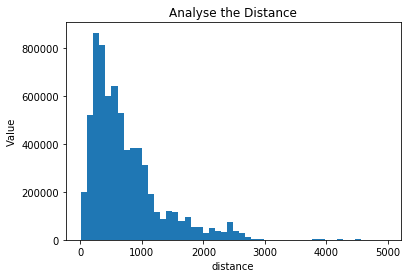

```python
plt.hist(data = df_clean, x = "Distance", bins = 50)
plt.ylabel("Value")
plt.xlabel("distance")
plt.title("Analyse the Distance");
```

```python
# The extremely high values  should be paid more attention. These can be outliers.
df_clean[df_clean.Distance > 3500].sample(5)
```

|  | Year | Month | DayofMonth | DayOfWeek | DepTime | CRSDepTime | ArrTime | UniqueCarrier | AirTime | ArrDelay | ... | Dest | Distance | Diverted | CarrierDelay | WeatherDelay | NASDelay | SecurityDelay | LateAircraftDelay | Date | Delayed |
| --- | --- | --- | --- | --- | --- | --- | --- | --- | --- | --- | --- | --- | --- | --- | --- | --- | --- | --- | --- | --- | --- |
| 6435191 | 2008 | 11 | 18 | 2 | 935.0 | 935 | 1358.0 | CO | 487.0 | -7.0 | ... | HNL | 3904 | 0 | NaN | NaN | NaN | NaN | NaN | 2008-11-18 | False |
| 5824636 | 2008 | 10 | 19 | 7 | 1244.0 | 1250 | 1548.0 | AA | 470.0 | -7.0 | ... | HNL | 3784 | 0 | NaN | NaN | NaN | NaN | NaN | 2008-10-19 | False |
| 1742535 | 2008 | 3 | 20 | 4 | 2150.0 | 2145 | 1304.0 | CO | 526.0 | -6.0 | ... | EWR | 4962 | 0 | NaN | NaN | NaN | NaN | NaN | 2008-03-20 | False |
| 594405 | 2008 | 1 | 6 | 7 | 1854.0 | 1900 | 835.0 | DL | 491.0 | -9.0 | ... | ATL | 4502 | 0 | NaN | NaN | NaN | NaN | NaN | 2008-01-06 | False |
| 2004553 | 2008 | 4 | 3 | 4 | 1657.0 | 1645 | 537.0 | UA | 440.0 | -4.0 | ... | ORD | 4213 | 0 | NaN | NaN | NaN | NaN | NaN | 2008-04-03 | False |

5 rows × 22 columns

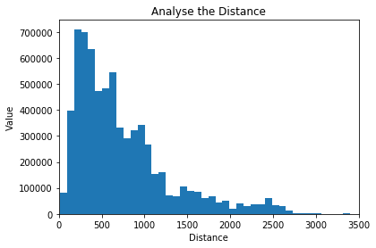

```python
# take a closer look at the data in the x-range between 0 and 3500.
# set x-limit betweeen 0 and 3500
plt.hist(data=df_clean, x="Distance", bins=60)
plt.xlabel("Distance")
plt.ylabel("Value")
plt.xlim([0,3500])
plt.title("Analyse the Distance");
```

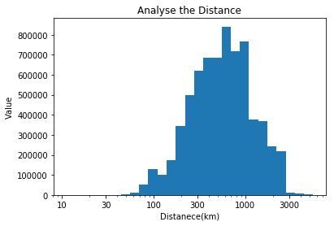

```python
#There is a long tail in the distribution, so put it on a log scale instead.

bin = 10 ** np.arange(np.log10(df.Distance.min()), np.log10(df.Distance.max())+0.1, 0.1)
plt.hist(data=df_clean, x="Distance", bins=bin)
plt.xscale("log")
plt.xlabel("Distanece(km)")
plt.ylabel("Value")
plt.xticks([10,30,100,300,1000,3000],[10,30,100,300,1000,3000])
plt.title("Analyse the Distance");
```

> Distance has a long-tailed distribution, with a lot of flights on the short distance end, and a few on the long-distance end. When plotted on a log-scale, the distance distribution looks roughly normal distribution with a distance ceiling at the right foot. This is simply because the longer the distance between airports is, the more limited flights there are.

## Bivariate Exploration

> **What is the relationship between the delayed flights and month**

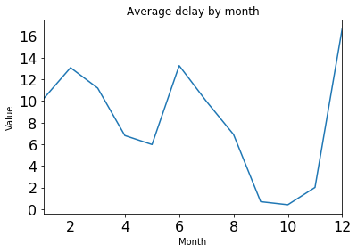

```python
df_clean[['Month','ArrDelay']].groupby(['Month']).mean().plot(kind='line',  grid=False,figsize=(6, 4),   fontsize=16)
plt.legend().remove()
plt.ylabel("Value")
plt.title('Average delay by month')
```

> Most delays happen in December. This is probably caused by the Christmas holidays. If we look at June and July (when the summer holidays start) it is also pretty high. However, during Christmas more people leave and travel to other states or countries. In March there is Easter that is why the number in March is also high.

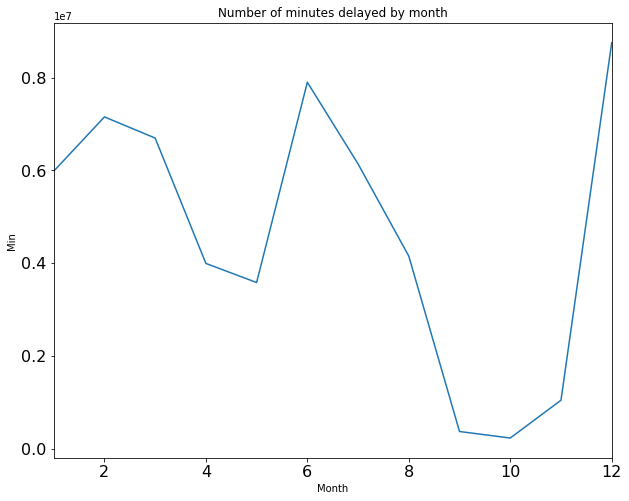

```python
df_clean[['Month','ArrDelay']].groupby(['Month']).sum().plot(kind='line', grid=False,figsize=(10, 8),  fontsize=16)
plt.legend().remove()
plt.ylabel("Min")
plt.title('Number of minutes delayed by month')
plt.show()
```

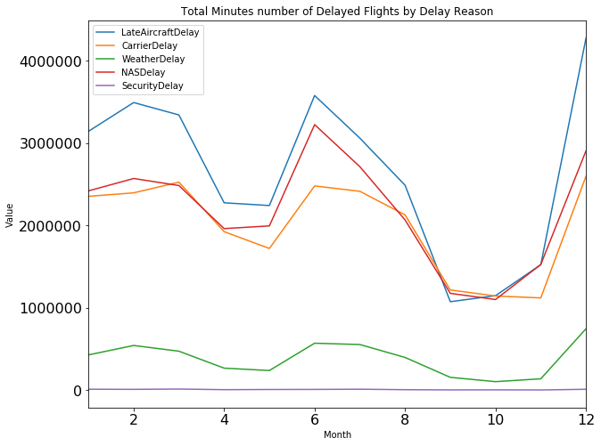

```python
df1 = df_clean.filter(['Month','CarrierDelay','WeatherDelay','NASDelay','SecurityDelay','LateAircraftDelay'], axis=1)
df1 = df1.groupby('Month')['LateAircraftDelay','CarrierDelay','WeatherDelay','NASDelay','SecurityDelay'].sum().plot(kind='line', figsize=(10, 8), grid= False, fontsize=16)
plt.title("Total Minutes number of Delayed Flights by Delay Reason")
plt.ylabel("Value")
plt.show();
```

> **The realtion between Delayed Flights and all Flights per week**

```python
df_flights_by_date = pd.DataFrame(df_clean.groupby('Date')['Year'].count())
df_flights_by_date.head(2)
```

| Date | Year |
| --- | --- |
| 2008-01-01 | 18597 |
| 2008-01-02 | 20428 |

```python
df_delayed_flights_by_date = pd.DataFrame(df_clean[df_clean['Delayed']==True].groupby('Date')['Year'].count())
df_delayed_flights_by_date.head()
```

| Date | Year |
| --- | --- |
| 2008-01-01 | 6099 |
| 2008-01-02 | 8128 |
| 2008-01-03 | 6396 |
| 2008-01-04 | 4834 |
| 2008-01-05 | 5046 |

```python
df_flights_by_date['Date1']=df_flights_by_date.index
df_delayed_flights_by_date['Date1']=df_delayed_flights_by_date.index
```

```python
df_flights_by_date_both=df_flights_by_date.merge(df_delayed_flights_by_date, how='inner', on='Date1')
df_flights_by_date_both.head(2)
```

|  | Year_x | Date1 | Year_y |
| --- | --- | --- | --- |
| 0 | 18597 | 2008-01-01 | 6099 |
| 1 | 20428 | 2008-01-02 | 8128 |

```python
df_flights_by_date_both=df_flights_by_date_both.rename(columns={'Year_x':'All_Flights', 'Year_y':'Delayed_Flights'})
```

```python
df_flights_by_date_both.head(2)
```

|  | All_Flights | Date1 | Delayed_Flights |
| --- | --- | --- | --- |
| 0 | 18597 | 2008-01-01 | 6099 |
| 1 | 20428 | 2008-01-02 | 8128 |

```python
df_flights_by_date_both['Week_Num']=df_flights_by_date_both['Date1'].apply(lambda x: x.isocalendar()[1])
```

```python
df_flights_by_week = df_flights_by_date_both[['Week_Num', 'All_Flights', 'Delayed_Flights']]
df_flights_by_week.head()
```

|  | Week_Num | All_Flights | Delayed_Flights |
| --- | --- | --- | --- |
| 0 | 1 | 18597 | 6099 |
| 1 | 1 | 20428 | 8128 |
| 2 | 1 | 20449 | 6396 |
| 3 | 1 | 20094 | 4834 |
| 4 | 1 | 17535 | 5046 |

```python
df_flights_by_week2=df_flights_by_week.groupby(['Week_Num']).sum()
df_flights_by_week2.head()
```

| Week_Num | All_Flights | Delayed_Flights |
| --- | --- | --- |
| 1 | 167890 | 46521 |
| 2 | 132793 | 21474 |
| 3 | 130790 | 23022 |
| 4 | 131164 | 30710 |
| 5 | 129036 | 29711 |

```python
df_flights_by_week2['Week_Num']= df_flights_by_week2.index
```

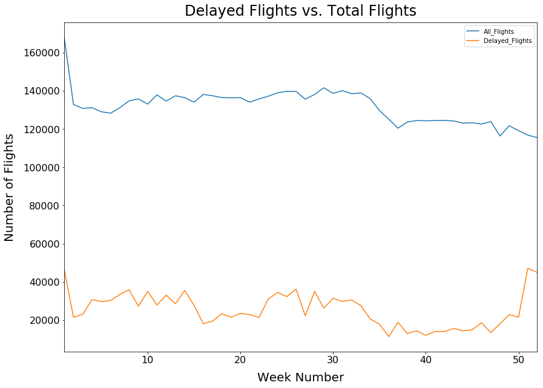

```python
#plt.style.use('fivethirtyeight')
df_flights_by_week2.set_index(['Week_Num']).plot(kind='line', figsize=(14, 10), grid= False, fontsize=16)
plt.title("Delayed Flights vs. Total Flights", fontsize=24, y=1.01)
plt.xlabel("Week Number", fontsize=20, labelpad=12)
plt.ylabel("Number of Flights", fontsize=20, labelpad=12)
```

> It is clear that there is a correlation between all flights and delayed flights as expected. Unusually, the volatility in the delayed curve not present in the all-flights curve indicates that delayed flights is not a perfect function of the total number of flights.

> **The relation between distance and AirTime**

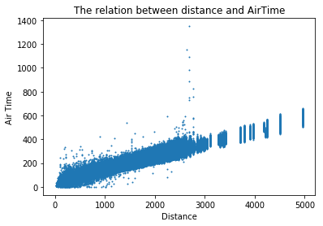

```python
plt.scatter(data=df_clean, x="Distance", y="AirTime",s=1)
plt.xlabel("Distance")
plt.ylabel("Air Time")
plt.title("The relation between distance and AirTime");
```

## Multivariate Exploration

> **Percentage of Flight Delays by Day and Hour of Day**

```python
df_clean['CRSDepTime1'] = df_clean['CRSDepTime'].apply(lambda x: '{0:0>4}'.format(x))  #pad with 0 to convert to hhmm
df_clean['CRSDepTime2'] = df_clean['CRSDepTime1'].astype(str)    #convert object to string
df_clean.CRSDepTime2 = df_clean.CRSDepTime2.str.slice(0, 2)     #Get Hour from CRS Dep time
df_clean['CRSDepTimeHr'] = df_clean['CRSDepTime2'].astype(int)
```

```python
#Create df with percent of flights that are delayed for each day of the week
df_delays_perc = pd.DataFrame(df_clean[df_clean['Delayed']==True].groupby(['DayOfWeek', 'CRSDepTimeHr'])['Year'].count()*100/df_clean.groupby(['DayOfWeek', 'CRSDepTimeHr'])['Year'].count())
df_delays_byhour = df_delays_perc.unstack(level=0)
```

```python
day_short_names = ['Mon', 'Tues', 'Wed', 'Thurs', 'Fri', 'Sat', 'Sun']
day_Hours = ['12am', '1am', '2am', '3am', '4am', '5am', '6am','7am','8am','9am', '10am', '11am', '12pm', '1pm', '2pm', '3pm', '4pm', '5pm', '6pm', '7pm', '8pm', '9pm', '10pm', '11pm']
```

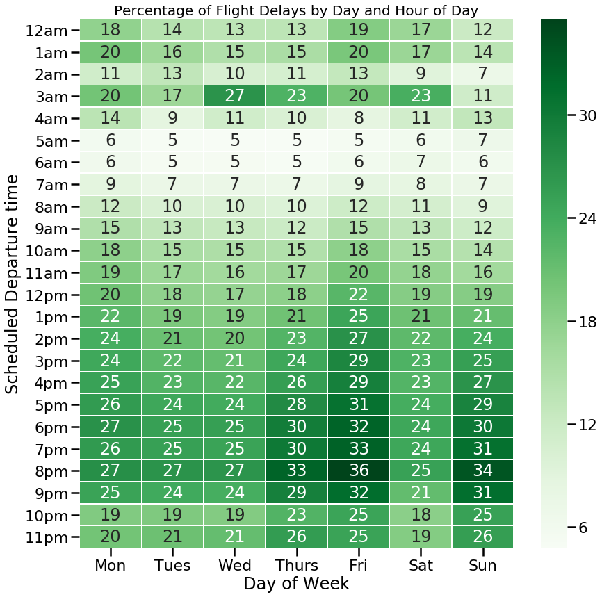

```python
#Create heatmap of the percent of flights delayed for each time of each day of the week
sns.set_context("poster")
f, ax = plt.subplots(figsize=(14, 14))
ax = sns.heatmap(df_delays_byhour, annot=True, fmt="0.0f", linewidths=.5, ax=ax, xticklabels=day_short_names, yticklabels=day_Hours, cmap="Greens")
ax.axes.set_title("Percentage of Flight Delays by Day and Hour of Day", fontsize=20, y=1.01)
ax.set(xlabel='Day of Week', ylabel='Scheduled Departure time');
```

> - Flights in the afternoon and evening are more delayed than early morning and night on any day of the week
> - Flights delays are maximum on Friday and Sunday evenings at 8 pm
> - The percentage of flights delayed at 3am shows higher than normal, but that is a result of bias created by considering percentages instead of the raw numbers.